[figure not shown]

# WHEAT SEED QUALITY DETECTION USING AI-ML

1. ETICALA SATWIK REDDY
2. MANTHENA KOUSHIK VARMA

### STEP 1: Read Dataset

```python
import pandas as pd
df = pd.read_csv ("wheat-seeds.csv")
```

```python
import warnings
warnings.filterwarnings("ignore")
```

```python
coulmn_names=[ "area A","perimeter P","compactness C ","length of kernel","width of kernel","asymmetry coefficient","length of kernel groove","seed_type"]
#naming the cloumns as per the data given.
df = pd.read_csv("wheat-seeds.csv", names=coulmn_names)
LABEL_MAP = {
    1: "white",
    2: "brown",
    3: "organic",
}
"""In the given csv file, we are taking the last attribute as type of seed. We are labelling 1 as white, 2 as brown and 3 as
    organic.
"""
for k,v in LABEL_MAP.items():
    df.ix[df.seed_type == k, 'seed_type'] = v
df
```

|  | area A | perimeter P | compactness C | length of kernel | width of kernel | asymmetry coefficient | length of kernel groove | seed_type |
| --- | --- | --- | --- | --- | --- | --- | --- | --- |
| 0 | 15.26 | 14.84 | 0.8710 | 5.763 | 3.312 | 2.2210 | 5.220 | white |
| 1 | 14.88 | 14.57 | 0.8811 | 5.554 | 3.333 | 1.0180 | 4.956 | white |
| 2 | 14.29 | 14.09 | 0.9050 | 5.291 | 3.337 | 2.6990 | 4.825 | white |
| 3 | 13.84 | 13.94 | 0.8955 | 5.324 | 3.379 | 2.2590 | 4.805 | white |
| 4 | 16.14 | 14.99 | 0.9034 | 5.658 | 3.562 | 1.3550 | 5.175 | white |
| 5 | 14.38 | 14.21 | 0.8951 | 5.386 | 3.312 | 2.4620 | 4.956 | white |
| 6 | 14.69 | 14.49 | 0.8799 | 5.563 | 3.259 | 3.5860 | 5.219 | white |
| 7 | 14.11 | 14.10 | 0.8911 | 5.420 | 3.302 | 2.7000 | 5.000 | white |
| 8 | 16.63 | 15.46 | 0.8747 | 6.053 | 3.465 | 2.0400 | 5.877 | white |
| 9 | 16.44 | 15.25 | 0.8880 | 5.884 | 3.505 | 1.9690 | 5.533 | white |
| 10 | 15.26 | 14.85 | 0.8696 | 5.714 | 3.242 | 4.5430 | 5.314 | white |
| 11 | 14.03 | 14.16 | 0.8796 | 5.438 | 3.201 | 1.7170 | 5.001 | white |
| 12 | 13.89 | 14.02 | 0.8880 | 5.439 | 3.199 | 3.9860 | 4.738 | white |
| 13 | 13.78 | 14.06 | 0.8759 | 5.479 | 3.156 | 3.1360 | 4.872 | white |
| 14 | 13.74 | 14.05 | 0.8744 | 5.482 | 3.114 | 2.9320 | 4.825 | white |
| 15 | 14.59 | 14.28 | 0.8993 | 5.351 | 3.333 | 4.1850 | 4.781 | white |
| 16 | 13.99 | 13.83 | 0.9183 | 5.119 | 3.383 | 5.2340 | 4.781 | white |
| 17 | 15.69 | 14.75 | 0.9058 | 5.527 | 3.514 | 1.5990 | 5.046 | white |
| 18 | 14.70 | 14.21 | 0.9153 | 5.205 | 3.466 | 1.7670 | 4.649 | white |
| 19 | 12.72 | 13.57 | 0.8686 | 5.226 | 3.049 | 4.1020 | 4.914 | white |
| 20 | 14.16 | 14.40 | 0.8584 | 5.658 | 3.129 | 3.0720 | 5.176 | white |
| 21 | 14.11 | 14.26 | 0.8722 | 5.520 | 3.168 | 2.6880 | 5.219 | white |
| 22 | 15.88 | 14.90 | 0.8988 | 5.618 | 3.507 | 0.7651 | 5.091 | white |
| 23 | 12.08 | 13.23 | 0.8664 | 5.099 | 2.936 | 1.4150 | 4.961 | white |
| 24 | 15.01 | 14.76 | 0.8657 | 5.789 | 3.245 | 1.7910 | 5.001 | white |
| 25 | 16.19 | 15.16 | 0.8849 | 5.833 | 3.421 | 0.9030 | 5.307 | white |
| 26 | 13.02 | 13.76 | 0.8641 | 5.395 | 3.026 | 3.3730 | 4.825 | white |
| 27 | 12.74 | 13.67 | 0.8564 | 5.395 | 2.956 | 2.5040 | 4.869 | white |
| 28 | 14.11 | 14.18 | 0.8820 | 5.541 | 3.221 | 2.7540 | 5.038 | white |
| 29 | 13.45 | 14.02 | 0.8604 | 5.516 | 3.065 | 3.5310 | 5.097 | white |
| ... | ... | ... | ... | ... | ... | ... | ... | ... |
| 180 | 11.41 | 12.95 | 0.8560 | 5.090 | 2.775 | 4.9570 | 4.825 | organic |
| 181 | 12.46 | 13.41 | 0.8706 | 5.236 | 3.017 | 4.9870 | 5.147 | organic |
| 182 | 12.19 | 13.36 | 0.8579 | 5.240 | 2.909 | 4.8570 | 5.158 | organic |
| 183 | 11.65 | 13.07 | 0.8575 | 5.108 | 2.850 | 5.2090 | 5.135 | organic |
| 184 | 12.89 | 13.77 | 0.8541 | 5.495 | 3.026 | 6.1850 | 5.316 | organic |
| 185 | 11.56 | 13.31 | 0.8198 | 5.363 | 2.683 | 4.0620 | 5.182 | organic |
| 186 | 11.81 | 13.45 | 0.8198 | 5.413 | 2.716 | 4.8980 | 5.352 | organic |
| 187 | 10.91 | 12.80 | 0.8372 | 5.088 | 2.675 | 4.1790 | 4.956 | organic |
| 188 | 11.23 | 12.82 | 0.8594 | 5.089 | 2.821 | 7.5240 | 4.957 | organic |
| 189 | 10.59 | 12.41 | 0.8648 | 4.899 | 2.787 | 4.9750 | 4.794 | organic |
| 190 | 10.93 | 12.80 | 0.8390 | 5.046 | 2.717 | 5.3980 | 5.045 | organic |
| 191 | 11.27 | 12.86 | 0.8563 | 5.091 | 2.804 | 3.9850 | 5.001 | organic |
| 192 | 11.87 | 13.02 | 0.8795 | 5.132 | 2.953 | 3.5970 | 5.132 | organic |
| 193 | 10.82 | 12.83 | 0.8256 | 5.180 | 2.630 | 4.8530 | 5.089 | organic |
| 194 | 12.11 | 13.27 | 0.8639 | 5.236 | 2.975 | 4.1320 | 5.012 | organic |
| 195 | 12.80 | 13.47 | 0.8860 | 5.160 | 3.126 | 4.8730 | 4.914 | organic |
| 196 | 12.79 | 13.53 | 0.8786 | 5.224 | 3.054 | 5.4830 | 4.958 | organic |
| 197 | 13.37 | 13.78 | 0.8849 | 5.320 | 3.128 | 4.6700 | 5.091 | organic |
| 198 | 12.62 | 13.67 | 0.8481 | 5.410 | 2.911 | 3.3060 | 5.231 | organic |
| 199 | 12.76 | 13.38 | 0.8964 | 5.073 | 3.155 | 2.8280 | 4.830 | organic |
| 200 | 12.38 | 13.44 | 0.8609 | 5.219 | 2.989 | 5.4720 | 5.045 | organic |
| 201 | 12.67 | 13.32 | 0.8977 | 4.984 | 3.135 | 2.3000 | 4.745 | organic |
| 202 | 11.18 | 12.72 | 0.8680 | 5.009 | 2.810 | 4.0510 | 4.828 | organic |
| 203 | 12.70 | 13.41 | 0.8874 | 5.183 | 3.091 | 8.4560 | 5.000 | organic |
| 204 | 12.37 | 13.47 | 0.8567 | 5.204 | 2.960 | 3.9190 | 5.001 | organic |
| 205 | 12.19 | 13.20 | 0.8783 | 5.137 | 2.981 | 3.6310 | 4.870 | organic |
| 206 | 11.23 | 12.88 | 0.8511 | 5.140 | 2.795 | 4.3250 | 5.003 | organic |
| 207 | 13.20 | 13.66 | 0.8883 | 5.236 | 3.232 | 8.3150 | 5.056 | organic |
| 208 | 11.84 | 13.21 | 0.8521 | 5.175 | 2.836 | 3.5980 | 5.044 | organic |
| 209 | 12.30 | 13.34 | 0.8684 | 5.243 | 2.974 | 5.6370 | 5.063 | organic |

210 rows × 8 columns

***Hence we can conclude that there is "No" missing data.

```python
df.groupby('seed_type')['seed_type'].count()  #number of seeds in each type
```

```
seed_type
brown      70
organic    70
white      70
Name: seed_type, dtype: int64
```

# STEP: 2:-Exploratory Data Analysis & Visulaization

Exploratory Data Analysis (EDA), also known as Data Exploration, is a step in the Data Analysis Process, where a number of techniques are used to better understand the dataset being used.

It includes:

==>Extracting important variables and leaving behind useless variables and Identifying outliers, missing values, or human error

==>Understanding the relationship(s), or lack of, between variables

==>Ultimately, maximizing your insights of a dataset and minimizing potential error that may occur later in the process

###### COMPONENTS OF EDA

1. UNDERSTANDING THE VARIABLES
2. CLEANSING DATASET
3. ANALYZING RELATIONSHIPS BETWEEN VARIABLES

###### 1. UNDERSTANDING THE VARIABLES

```python
# importing the required libraries
import numpy as np
import pandas as pd
%matplotlib inline
import matplotlib.pylab as plt
import seaborn as sns
```

```python
#understanding variables
df.head() #returns the first 5 rows of my dataset
```

|  | area A | perimeter P | compactness C | length of kernel | width of kernel | asymmetry coefficient | length of kernel groove | seed_type |
| --- | --- | --- | --- | --- | --- | --- | --- | --- |
| 0 | 15.26 | 14.84 | 0.8710 | 5.763 | 3.312 | 2.221 | 5.220 | white |
| 1 | 14.88 | 14.57 | 0.8811 | 5.554 | 3.333 | 1.018 | 4.956 | white |
| 2 | 14.29 | 14.09 | 0.9050 | 5.291 | 3.337 | 2.699 | 4.825 | white |
| 3 | 13.84 | 13.94 | 0.8955 | 5.324 | 3.379 | 2.259 | 4.805 | white |
| 4 | 16.14 | 14.99 | 0.9034 | 5.658 | 3.562 | 1.355 | 5.175 | white |

```python
df.tail()  #returns the last 5 rows of my dataset
```

|  | area A | perimeter P | compactness C | length of kernel | width of kernel | asymmetry coefficient | length of kernel groove | seed_type |
| --- | --- | --- | --- | --- | --- | --- | --- | --- |
| 205 | 12.19 | 13.20 | 0.8783 | 5.137 | 2.981 | 3.631 | 4.870 | organic |
| 206 | 11.23 | 12.88 | 0.8511 | 5.140 | 2.795 | 4.325 | 5.003 | organic |
| 207 | 13.20 | 13.66 | 0.8883 | 5.236 | 3.232 | 8.315 | 5.056 | organic |
| 208 | 11.84 | 13.21 | 0.8521 | 5.175 | 2.836 | 3.598 | 5.044 | organic |
| 209 | 12.30 | 13.34 | 0.8684 | 5.243 | 2.974 | 5.637 | 5.063 | organic |

```python
df.columns #returns the names of the columns of my dataset
```

```
Index(['area A', 'perimeter P', 'compactness C ', 'length of kernel',
       'width of kernel', 'asymmetry coefficient', 'length of kernel groove',
       'seed_type'],
      dtype='object')
```

```python
df.shape #returns the number of rows by the number of columns of dataset
```

```
(210, 8)
```

```python
df.describe()   #summarizes the count, mean, standard deviation, min and max for numeric variables
```

|  | area A | perimeter P | compactness C | length of kernel | width of kernel | asymmetry coefficient | length of kernel groove |
| --- | --- | --- | --- | --- | --- | --- | --- |
| count | 210.000000 | 210.000000 | 210.000000 | 210.000000 | 210.000000 | 210.000000 | 210.000000 |
| mean | 14.847524 | 14.559286 | 0.870999 | 5.628533 | 3.258605 | 3.700201 | 5.408071 |
| std | 2.909699 | 1.305959 | 0.023629 | 0.443063 | 0.377714 | 1.503557 | 0.491480 |
| min | 10.590000 | 12.410000 | 0.808100 | 4.899000 | 2.630000 | 0.765100 | 4.519000 |
| 25% | 12.270000 | 13.450000 | 0.856900 | 5.262250 | 2.944000 | 2.561500 | 5.045000 |
| 50% | 14.355000 | 14.320000 | 0.873450 | 5.523500 | 3.237000 | 3.599000 | 5.223000 |
| 75% | 17.305000 | 15.715000 | 0.887775 | 5.979750 | 3.561750 | 4.768750 | 5.877000 |
| max | 21.180000 | 17.250000 | 0.918300 | 6.675000 | 4.033000 | 8.456000 | 6.550000 |

```python
df.nunique(axis=0) #returns the number of unique vlaues for each variable
```

```
area A                     193
perimeter P                170
compactness C              186
length of kernel           188
width of kernel            184
asymmetry coefficient      207
length of kernel groove    148
seed_type                    3
dtype: int64
```

###### 2. Cleansing the dataset--checking for missing values

CHECKING ROWS WITH NULL VALUES

```python
df.isnull() #checking for null values
```

|  | area A | perimeter P | compactness C | length of kernel | width of kernel | asymmetry coefficient | length of kernel groove | seed_type |
| --- | --- | --- | --- | --- | --- | --- | --- | --- |
| 0 | False | False | False | False | False | False | False | False |
| 1 | False | False | False | False | False | False | False | False |
| 2 | False | False | False | False | False | False | False | False |
| 3 | False | False | False | False | False | False | False | False |
| 4 | False | False | False | False | False | False | False | False |
| 5 | False | False | False | False | False | False | False | False |
| 6 | False | False | False | False | False | False | False | False |
| 7 | False | False | False | False | False | False | False | False |
| 8 | False | False | False | False | False | False | False | False |
| 9 | False | False | False | False | False | False | False | False |
| 10 | False | False | False | False | False | False | False | False |
| 11 | False | False | False | False | False | False | False | False |
| 12 | False | False | False | False | False | False | False | False |
| 13 | False | False | False | False | False | False | False | False |
| 14 | False | False | False | False | False | False | False | False |
| 15 | False | False | False | False | False | False | False | False |
| 16 | False | False | False | False | False | False | False | False |
| 17 | False | False | False | False | False | False | False | False |
| 18 | False | False | False | False | False | False | False | False |
| 19 | False | False | False | False | False | False | False | False |
| 20 | False | False | False | False | False | False | False | False |
| 21 | False | False | False | False | False | False | False | False |
| 22 | False | False | False | False | False | False | False | False |
| 23 | False | False | False | False | False | False | False | False |
| 24 | False | False | False | False | False | False | False | False |
| 25 | False | False | False | False | False | False | False | False |
| 26 | False | False | False | False | False | False | False | False |
| 27 | False | False | False | False | False | False | False | False |
| 28 | False | False | False | False | False | False | False | False |
| 29 | False | False | False | False | False | False | False | False |
| ... | ... | ... | ... | ... | ... | ... | ... | ... |
| 180 | False | False | False | False | False | False | False | False |
| 181 | False | False | False | False | False | False | False | False |
| 182 | False | False | False | False | False | False | False | False |
| 183 | False | False | False | False | False | False | False | False |
| 184 | False | False | False | False | False | False | False | False |
| 185 | False | False | False | False | False | False | False | False |
| 186 | False | False | False | False | False | False | False | False |
| 187 | False | False | False | False | False | False | False | False |
| 188 | False | False | False | False | False | False | False | False |
| 189 | False | False | False | False | False | False | False | False |
| 190 | False | False | False | False | False | False | False | False |
| 191 | False | False | False | False | False | False | False | False |
| 192 | False | False | False | False | False | False | False | False |
| 193 | False | False | False | False | False | False | False | False |
| 194 | False | False | False | False | False | False | False | False |
| 195 | False | False | False | False | False | False | False | False |
| 196 | False | False | False | False | False | False | False | False |
| 197 | False | False | False | False | False | False | False | False |
| 198 | False | False | False | False | False | False | False | False |
| 199 | False | False | False | False | False | False | False | False |
| 200 | False | False | False | False | False | False | False | False |
| 201 | False | False | False | False | False | False | False | False |
| 202 | False | False | False | False | False | False | False | False |
| 203 | False | False | False | False | False | False | False | False |
| 204 | False | False | False | False | False | False | False | False |
| 205 | False | False | False | False | False | False | False | False |
| 206 | False | False | False | False | False | False | False | False |
| 207 | False | False | False | False | False | False | False | False |
| 208 | False | False | False | False | False | False | False | False |
| 209 | False | False | False | False | False | False | False | False |

210 rows × 8 columns

No null values have been found.

###### 3.Analyzing relationships between variables

Correlation matrix

Correlation matrix is a table that shows the correlation coefficients between many variables

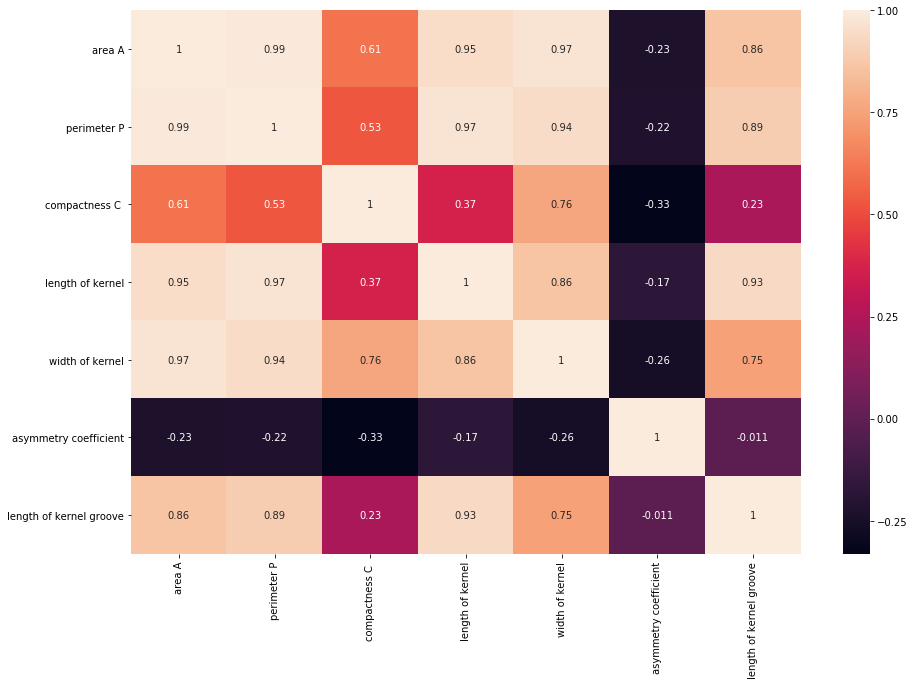

```python
import seaborn as sns
#plotting the correlation matrix using sns.heatmap()
plt.figure(figsize=(15,10))
sns.heatmap(df.corr(),annot=True)
```

Scatterplot

A scatterplot is a type of graph which ‘plots’ the values of two variables along two axes, like age and height.

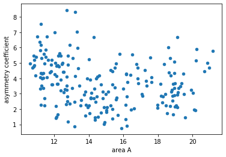

```python
df.plot(kind='scatter', x='area A', y='asymmetry coefficient')
```

The above scatterplot will make us understand about, how area is effecting the assymetry coefficient of a wheat grain.

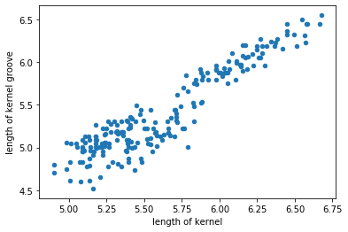

```python
df.plot(kind='scatter', x='length of kernel', y='length of kernel groove')
```

The above plot will give a clear understanding how the length of kernel is showing its effect on lenghth of kernel groove.

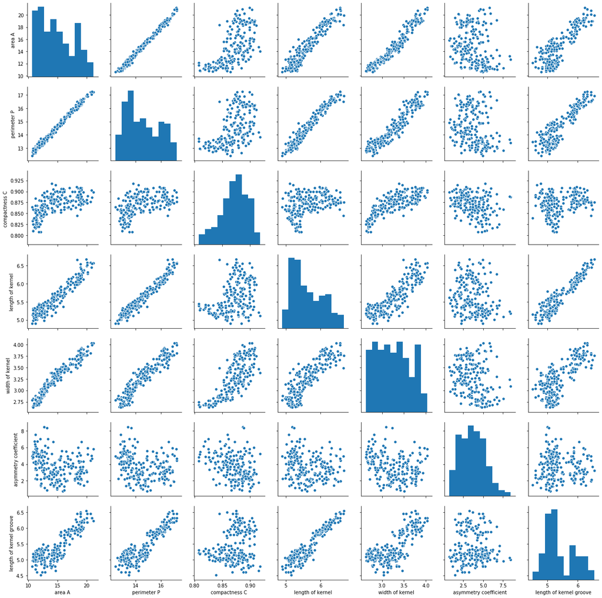

```python
sns.pairplot(df) #creating scatterplots between all the variables
```

Parallel coordinates

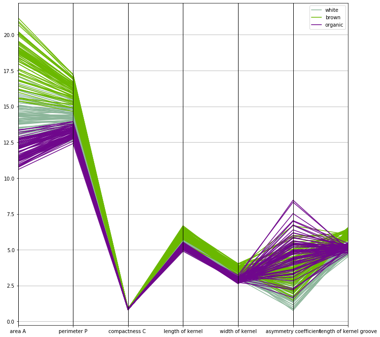

```python
from pandas.plotting import parallel_coordinates
plt.figure(figsize=(12,12))
parallel_coordinates(df, 'seed_type')
plt.show()
```

The above graph will show the comparison between various variables with the type of seed, i.e white,brown and organic parallely in a single graph.

### 3.Split Data for Training and Testing

```python
from sklearn.model_selection import train_test_split
```

```python
from sklearn.model_selection import train_test_split
x_train, x_test, y_train, y_test = train_test_split(df.drop('seed_type',axis=1),
                                                    df['seed_type'], test_size=0.30,
                                                    random_state=101)
```

```python
x_train   #Data for training
```

|  | area A | perimeter P | compactness C | length of kernel | width of kernel | asymmetry coefficient | length of kernel groove |
| --- | --- | --- | --- | --- | --- | --- | --- |
| 33 | 13.94 | 14.17 | 0.8728 | 5.585 | 3.150 | 2.124 | 5.012 |
| 45 | 13.80 | 14.04 | 0.8794 | 5.376 | 3.155 | 1.560 | 4.961 |
| 196 | 12.79 | 13.53 | 0.8786 | 5.224 | 3.054 | 5.483 | 4.958 |
| 208 | 11.84 | 13.21 | 0.8521 | 5.175 | 2.836 | 3.598 | 5.044 |
| 53 | 14.33 | 14.28 | 0.8831 | 5.504 | 3.199 | 3.328 | 5.224 |
| 93 | 18.59 | 16.05 | 0.9066 | 6.037 | 3.860 | 6.001 | 5.877 |
| 100 | 16.41 | 15.25 | 0.8866 | 5.718 | 3.525 | 4.217 | 5.618 |
| 165 | 12.10 | 13.15 | 0.8793 | 5.105 | 2.941 | 2.201 | 5.056 |
| 150 | 11.83 | 13.23 | 0.8496 | 5.263 | 2.840 | 5.195 | 5.307 |
| 155 | 11.19 | 13.05 | 0.8253 | 5.250 | 2.675 | 5.813 | 5.219 |
| 64 | 12.78 | 13.57 | 0.8716 | 5.262 | 3.026 | 1.176 | 4.782 |
| 135 | 15.38 | 14.66 | 0.8990 | 5.477 | 3.465 | 3.600 | 5.439 |
| 24 | 15.01 | 14.76 | 0.8657 | 5.789 | 3.245 | 1.791 | 5.001 |
| 80 | 16.53 | 15.34 | 0.8823 | 5.875 | 3.467 | 5.532 | 5.880 |
| 129 | 17.55 | 15.66 | 0.8991 | 5.791 | 3.690 | 5.366 | 5.661 |
| 13 | 13.78 | 14.06 | 0.8759 | 5.479 | 3.156 | 3.136 | 4.872 |
| 52 | 14.49 | 14.61 | 0.8538 | 5.715 | 3.113 | 4.116 | 5.396 |
| 119 | 20.03 | 16.90 | 0.8811 | 6.493 | 3.857 | 3.063 | 6.320 |
| 174 | 10.83 | 12.96 | 0.8099 | 5.278 | 2.641 | 5.182 | 5.185 |
| 56 | 14.46 | 14.35 | 0.8818 | 5.388 | 3.377 | 2.802 | 5.044 |
| 118 | 18.89 | 16.23 | 0.9008 | 6.227 | 3.769 | 3.639 | 5.966 |
| 173 | 11.40 | 13.08 | 0.8375 | 5.136 | 2.763 | 5.588 | 5.089 |
| 176 | 11.26 | 13.01 | 0.8355 | 5.186 | 2.710 | 5.335 | 5.092 |
| 167 | 12.15 | 13.45 | 0.8443 | 5.417 | 2.837 | 3.638 | 5.338 |
| 169 | 11.24 | 13.00 | 0.8359 | 5.090 | 2.715 | 3.521 | 5.088 |
| 191 | 11.27 | 12.86 | 0.8563 | 5.091 | 2.804 | 3.985 | 5.001 |
| 194 | 12.11 | 13.27 | 0.8639 | 5.236 | 2.975 | 4.132 | 5.012 |
| 203 | 12.70 | 13.41 | 0.8874 | 5.183 | 3.091 | 8.456 | 5.000 |
| 27 | 12.74 | 13.67 | 0.8564 | 5.395 | 2.956 | 2.504 | 4.869 |
| 145 | 11.21 | 13.13 | 0.8167 | 5.279 | 2.687 | 6.169 | 5.275 |
| ... | ... | ... | ... | ... | ... | ... | ... |
| 19 | 12.72 | 13.57 | 0.8686 | 5.226 | 3.049 | 4.102 | 4.914 |
| 72 | 17.26 | 15.73 | 0.8763 | 5.978 | 3.594 | 4.539 | 5.791 |
| 44 | 15.11 | 14.54 | 0.8986 | 5.579 | 3.462 | 3.128 | 5.180 |
| 162 | 12.05 | 13.41 | 0.8416 | 5.267 | 2.847 | 4.988 | 5.046 |
| 59 | 12.11 | 13.47 | 0.8392 | 5.159 | 3.032 | 1.502 | 4.519 |
| 187 | 10.91 | 12.80 | 0.8372 | 5.088 | 2.675 | 4.179 | 4.956 |
| 157 | 12.13 | 13.73 | 0.8081 | 5.394 | 2.745 | 4.825 | 5.220 |
| 115 | 19.06 | 16.45 | 0.8854 | 6.416 | 3.719 | 2.248 | 6.163 |
| 136 | 17.36 | 15.76 | 0.8785 | 6.145 | 3.574 | 3.526 | 5.971 |
| 111 | 19.38 | 16.72 | 0.8716 | 6.303 | 3.791 | 3.678 | 5.965 |
| 83 | 19.57 | 16.74 | 0.8779 | 6.384 | 3.772 | 1.472 | 6.273 |
| 49 | 14.86 | 14.67 | 0.8676 | 5.678 | 3.258 | 2.129 | 5.351 |
| 201 | 12.67 | 13.32 | 0.8977 | 4.984 | 3.135 | 2.300 | 4.745 |
| 140 | 13.07 | 13.92 | 0.8480 | 5.472 | 2.994 | 5.304 | 5.395 |
| 5 | 14.38 | 14.21 | 0.8951 | 5.386 | 3.312 | 2.462 | 4.956 |
| 110 | 18.45 | 16.12 | 0.8921 | 6.107 | 3.769 | 2.235 | 5.794 |
| 192 | 11.87 | 13.02 | 0.8795 | 5.132 | 2.953 | 3.597 | 5.132 |
| 60 | 11.42 | 12.86 | 0.8683 | 5.008 | 2.850 | 2.700 | 4.607 |
| 168 | 11.35 | 13.12 | 0.8291 | 5.176 | 2.668 | 4.337 | 5.132 |
| 205 | 12.19 | 13.20 | 0.8783 | 5.137 | 2.981 | 3.631 | 4.870 |
| 132 | 15.38 | 14.90 | 0.8706 | 5.884 | 3.268 | 4.462 | 5.795 |
| 40 | 13.54 | 13.85 | 0.8871 | 5.348 | 3.156 | 2.587 | 5.178 |
| 137 | 15.57 | 15.15 | 0.8527 | 5.920 | 3.231 | 2.640 | 5.879 |
| 75 | 16.77 | 15.62 | 0.8638 | 5.927 | 3.438 | 4.920 | 5.795 |
| 87 | 18.98 | 16.66 | 0.8590 | 6.549 | 3.670 | 3.691 | 6.498 |
| 63 | 13.22 | 13.84 | 0.8680 | 5.395 | 3.070 | 4.157 | 5.088 |
| 70 | 17.63 | 15.98 | 0.8673 | 6.191 | 3.561 | 4.076 | 6.060 |
| 81 | 18.72 | 16.19 | 0.8977 | 6.006 | 3.857 | 5.324 | 5.879 |
| 11 | 14.03 | 14.16 | 0.8796 | 5.438 | 3.201 | 1.717 | 5.001 |
| 95 | 16.87 | 15.65 | 0.8648 | 6.139 | 3.463 | 3.696 | 5.967 |

147 rows × 7 columns

```python
x_test  #splitting data for testing
```

|  | area A | perimeter P | compactness C | length of kernel | width of kernel | asymmetry coefficient | length of kernel groove |
| --- | --- | --- | --- | --- | --- | --- | --- |
| 123 | 18.43 | 15.97 | 0.9077 | 5.980 | 3.771 | 2.9840 | 5.905 |
| 134 | 15.56 | 14.89 | 0.8823 | 5.776 | 3.408 | 4.9720 | 5.847 |
| 184 | 12.89 | 13.77 | 0.8541 | 5.495 | 3.026 | 6.1850 | 5.316 |
| 125 | 18.75 | 16.18 | 0.8999 | 6.111 | 3.869 | 4.1880 | 5.992 |
| 189 | 10.59 | 12.41 | 0.8648 | 4.899 | 2.787 | 4.9750 | 4.794 |
| 154 | 11.36 | 13.05 | 0.8382 | 5.175 | 2.755 | 4.0480 | 5.263 |
| 188 | 11.23 | 12.82 | 0.8594 | 5.089 | 2.821 | 7.5240 | 4.957 |
| 89 | 20.88 | 17.05 | 0.9031 | 6.450 | 4.032 | 5.0160 | 6.321 |
| 37 | 17.08 | 15.38 | 0.9079 | 5.832 | 3.683 | 2.9560 | 5.484 |
| 34 | 15.05 | 14.68 | 0.8779 | 5.712 | 3.328 | 2.1290 | 5.360 |
| 149 | 10.79 | 12.93 | 0.8107 | 5.317 | 2.648 | 5.4620 | 5.194 |
| 65 | 12.88 | 13.50 | 0.8879 | 5.139 | 3.119 | 2.3520 | 4.607 |
| 78 | 18.94 | 16.49 | 0.8750 | 6.445 | 3.639 | 5.0640 | 6.362 |
| 156 | 11.34 | 12.87 | 0.8596 | 5.053 | 2.849 | 3.3470 | 5.003 |
| 144 | 11.82 | 13.40 | 0.8274 | 5.314 | 2.777 | 4.4710 | 5.178 |
| 66 | 14.34 | 14.37 | 0.8726 | 5.630 | 3.190 | 1.3130 | 5.150 |
| 85 | 18.27 | 16.09 | 0.8870 | 6.173 | 3.651 | 2.4430 | 6.197 |
| 177 | 10.74 | 12.73 | 0.8329 | 5.145 | 2.642 | 4.7020 | 4.963 |
| 31 | 15.49 | 14.94 | 0.8724 | 5.757 | 3.371 | 3.4120 | 5.228 |
| 91 | 18.76 | 16.20 | 0.8984 | 6.172 | 3.796 | 3.1200 | 6.053 |
| 42 | 13.16 | 13.55 | 0.9009 | 5.138 | 3.201 | 2.4610 | 4.783 |
| 41 | 13.50 | 13.85 | 0.8852 | 5.351 | 3.158 | 2.2490 | 5.176 |
| 186 | 11.81 | 13.45 | 0.8198 | 5.413 | 2.716 | 4.8980 | 5.352 |
| 54 | 14.52 | 14.60 | 0.8557 | 5.741 | 3.113 | 1.4810 | 5.487 |
| 171 | 11.55 | 13.10 | 0.8455 | 5.167 | 2.845 | 6.7150 | 4.956 |
| 48 | 14.79 | 14.52 | 0.8819 | 5.545 | 3.291 | 2.7040 | 5.111 |
| 50 | 14.43 | 14.40 | 0.8751 | 5.585 | 3.272 | 3.9750 | 5.144 |
| 183 | 11.65 | 13.07 | 0.8575 | 5.108 | 2.850 | 5.2090 | 5.135 |
| 153 | 11.18 | 13.04 | 0.8266 | 5.220 | 2.693 | 3.3320 | 5.001 |
| 148 | 12.70 | 13.71 | 0.8491 | 5.386 | 2.911 | 3.2600 | 5.316 |
| ... | ... | ... | ... | ... | ... | ... | ... |
| 2 | 14.29 | 14.09 | 0.9050 | 5.291 | 3.337 | 2.6990 | 4.825 |
| 12 | 13.89 | 14.02 | 0.8880 | 5.439 | 3.199 | 3.9860 | 4.738 |
| 141 | 13.32 | 13.94 | 0.8613 | 5.541 | 3.073 | 7.0350 | 5.440 |
| 151 | 12.01 | 13.52 | 0.8249 | 5.405 | 2.776 | 6.9920 | 5.270 |
| 22 | 15.88 | 14.90 | 0.8988 | 5.618 | 3.507 | 0.7651 | 5.091 |
| 102 | 19.46 | 16.50 | 0.8985 | 6.113 | 3.892 | 4.3080 | 6.009 |
| 39 | 14.28 | 14.17 | 0.8944 | 5.397 | 3.298 | 6.6850 | 5.001 |
| 32 | 14.09 | 14.41 | 0.8529 | 5.717 | 3.186 | 3.9200 | 5.299 |
| 147 | 12.49 | 13.46 | 0.8658 | 5.267 | 2.967 | 4.4210 | 5.002 |
| 74 | 16.82 | 15.51 | 0.8786 | 6.017 | 3.486 | 4.0040 | 5.841 |
| 166 | 12.44 | 13.59 | 0.8462 | 5.319 | 2.897 | 4.9240 | 5.270 |
| 127 | 17.98 | 15.85 | 0.8993 | 5.979 | 3.687 | 2.2570 | 5.919 |
| 16 | 13.99 | 13.83 | 0.9183 | 5.119 | 3.383 | 5.2340 | 4.781 |
| 209 | 12.30 | 13.34 | 0.8684 | 5.243 | 2.974 | 5.6370 | 5.063 |
| 152 | 12.26 | 13.60 | 0.8333 | 5.408 | 2.833 | 4.7560 | 5.360 |
| 133 | 16.16 | 15.33 | 0.8644 | 5.845 | 3.395 | 4.2660 | 5.795 |
| 96 | 19.31 | 16.59 | 0.8815 | 6.341 | 3.810 | 3.4770 | 6.238 |
| 18 | 14.70 | 14.21 | 0.9153 | 5.205 | 3.466 | 1.7670 | 4.649 |
| 61 | 11.23 | 12.63 | 0.8840 | 4.902 | 2.879 | 2.2690 | 4.703 |
| 108 | 19.94 | 16.92 | 0.8752 | 6.675 | 3.763 | 3.2520 | 6.550 |
| 4 | 16.14 | 14.99 | 0.9034 | 5.658 | 3.562 | 1.3550 | 5.175 |
| 15 | 14.59 | 14.28 | 0.8993 | 5.351 | 3.333 | 4.1850 | 4.781 |
| 1 | 14.88 | 14.57 | 0.8811 | 5.554 | 3.333 | 1.0180 | 4.956 |
| 43 | 15.50 | 14.86 | 0.8820 | 5.877 | 3.396 | 4.7110 | 5.528 |
| 131 | 18.94 | 16.32 | 0.8942 | 6.144 | 3.825 | 2.9080 | 5.949 |
| 181 | 12.46 | 13.41 | 0.8706 | 5.236 | 3.017 | 4.9870 | 5.147 |
| 9 | 16.44 | 15.25 | 0.8880 | 5.884 | 3.505 | 1.9690 | 5.533 |
| 163 | 12.55 | 13.57 | 0.8558 | 5.333 | 2.968 | 4.4190 | 5.176 |
| 36 | 16.20 | 15.27 | 0.8734 | 5.826 | 3.464 | 2.8230 | 5.527 |
| 90 | 20.10 | 16.99 | 0.8746 | 6.581 | 3.785 | 1.9550 | 6.449 |

63 rows × 7 columns

### 4.Apply different Classification Algorithms and tune them

support vector machine

```python
from sklearn.svm import SVC
model=SVC()
model.fit(x_train,y_train)
predictions=model.predict(x_test)
```

K nearest neighbours

```python
from sklearn.neighbors import KNeighborsClassifier
classifier = KNeighborsClassifier(n_neighbors=5)
classifier.fit(x_train, y_train)
y_pred = classifier.predict(x_test)
```

Decision Trees

```python
from sklearn.tree import DecisionTreeClassifier
model1 = DecisionTreeClassifier(max_depth = 6,random_state = 0,criterion = "entropy")
model1.fit(x_train, y_train)
predictions2=model1.predict(x_test)
```

Logistic Regression

```python
from sklearn.linear_model import LogisticRegression
logmodel = LogisticRegression(max_iter=800)
logmodel = LogisticRegression(solver='liblinear')
logmodel.fit(x_train,y_train)
predictions1 = logmodel.predict(x_test)
```

Hyper parameter tuning in support Vector machine

```python
from sklearn.model_selection import GridSearchCV
grid_parameters = {'C': [0.001,0.1,1, 10, 100, 1000], 'gamma': [0.0001, 0.001, 0.01, 0.1, 1, 10, 100]}
grid = GridSearchCV(SVC(),grid_parameters,verbose=1)
grid.fit(x_train,y_train)
grid_predictions = grid.predict(x_test)
```

```
Fitting 3 folds for each of 42 candidates, totalling 126 fits
```

[output not shown]

Hyper parameter tuning in Logistic regression

```python
from sklearn.model_selection import GridSearchCV
params = {'penalty' : ['l1', 'l2'],'C' : np.logspace(-4, 4, 20),'solver' : ['liblinear']}
grid1 = GridSearchCV(LogisticRegression(),params,verbose=1)
grid1.fit(x_train,y_train)
grid_predictions1 = grid1.predict(x_test)
```

```
[Parallel(n_jobs=1)]: Using backend SequentialBackend with 1 concurrent workers.
```

```
Fitting 3 folds for each of 40 candidates, totalling 120 fits
```

[output not shown]

Hyper paramter tuning in K nearest neighbours

```python
from sklearn.model_selection import GridSearchCV
params =  {
    'n_neighbors': (1,10, 1),
    'leaf_size': (20,40,1),
    'p': (1,2),
    'weights': ('uniform', 'distance'),
    'metric': ('minkowski', 'chebyshev')}
grid2 = GridSearchCV(KNeighborsClassifier(),params,verbose=1)
grid2.fit(x_train,y_train)
grid_predictions2 = grid2.predict(x_test)
```

```
Fitting 3 folds for each of 72 candidates, totalling 216 fits
```

[output not shown]

#### 5.PERFORAMANCE METRICS

```python
from sklearn.metrics import classification_report
```

```python
#---------------SUPPORT VECTOR MACHINE ---------------#
print(classification_report(y_test,predictions))
```

```
              precision    recall  f1-score   support

       brown       0.83      1.00      0.91        15
     organic       0.88      1.00      0.94        22
       white       1.00      0.77      0.87        26

    accuracy                           0.90        63
   macro avg       0.90      0.92      0.90        63
weighted avg       0.92      0.90      0.90        63
```

```python
#-----------LOGISTIC REGRESSION--------------#

print(classification_report(y_test,predictions1))
```

```
              precision    recall  f1-score   support

       brown       0.83      1.00      0.91        15
     organic       0.92      1.00      0.96        22
       white       1.00      0.81      0.89        26

    accuracy                           0.92        63
   macro avg       0.92      0.94      0.92        63
weighted avg       0.93      0.92      0.92        63
```

```python
#---------------Descision Tree---------------#
print(classification_report(y_test,predictions2))
```

```
              precision    recall  f1-score   support

       brown       1.00      1.00      1.00        15
     organic       0.88      0.95      0.91        22
       white       0.96      0.88      0.92        26

    accuracy                           0.94        63
   macro avg       0.94      0.95      0.94        63
weighted avg       0.94      0.94      0.94        63
```

```python
# ---------- nearest neighbors --------------------#

print(classification_report(y_test,y_pred))
```

```
              precision    recall  f1-score   support

       brown       0.83      1.00      0.91        15
     organic       0.85      1.00      0.92        22
       white       1.00      0.73      0.84        26

    accuracy                           0.89        63
   macro avg       0.89      0.91      0.89        63
weighted avg       0.91      0.89      0.89        63
```

```python
# -----svm after tuning------#

print(classification_report(y_test,grid_predictions))
```

```
              precision    recall  f1-score   support

       brown       0.88      1.00      0.94        15
     organic       0.96      1.00      0.98        22
       white       1.00      0.88      0.94        26

    accuracy                           0.95        63
   macro avg       0.95      0.96      0.95        63
weighted avg       0.96      0.95      0.95        63
```

```python
#-------- logistic regression after tuning---------#

print(classification_report(y_test,grid_predictions1))
```

```
              precision    recall  f1-score   support

       brown       1.00      1.00      1.00        15
     organic       0.88      1.00      0.94        22
       white       1.00      0.88      0.94        26

    accuracy                           0.95        63
   macro avg       0.96      0.96      0.96        63
weighted avg       0.96      0.95      0.95        63
```

```python
#c-------- k nearest neigbours after tuning--------#

print(classification_report(y_test,grid_predictions2))
```

```
              precision    recall  f1-score   support

       brown       0.79      1.00      0.88        15
     organic       0.88      1.00      0.94        22
       white       1.00      0.73      0.84        26

    accuracy                           0.89        63
   macro avg       0.89      0.91      0.89        63
weighted avg       0.91      0.89      0.89        63
```

### 6.Visually compare the performance of all classifiers

```
Fitting 3 folds for each of 42 candidates, totalling 126 fits
```

[output not shown]

```
Fitting 3 folds for each of 72 candidates, totalling 216 fits
```

[output not shown]

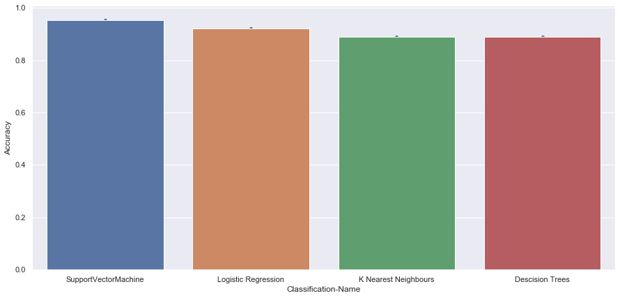

```python
types=["SupportVectorMachine","Logistic Regression","K Nearest Neighbours","Descision Trees"]
classifiers=[grid,LogisticRegression(),grid2,DecisionTreeClassifier()]


accuracy= []
for name,clf in zip(types,classifiers):
    clf.fit(x_train,y_train)
    score=clf.score(x_test,y_test)
    accuracy.append(score)



df_check=pd.DataFrame()
df_check["Classification-Name"]=types
df_check["Accuracy"]=accuracy

plt.figure(figsize=(15, 7))
sns.set(style="darkgrid")
ax=sns.scatterplot(x="Classification-Name",y="Accuracy",data=df_check)
ax=sns.barplot(x="Classification-Name",y="Accuracy",data=df_check)
#plotting the bar graph to betterly understand the best suitable method of classification
```

Note : We included the algorithm and future scope of improvement of in the Project Report.(.DOCX file)